# Semester 4 Coding Portfolio Part 8: Correlation, clustering and PSM

This notebook covers the following topics:

- Correlation functions
- Clustering with plots
- Propensity Score Matching

This notebook is expected to take around 20 hours to complete:

- 4 hours for the formative part
- 6 hours of self-study on the topics covered by this notebook
- 10 hours for the summative part of this notebook

Like all notebooks in this portfolio, it is split into two sections:

- Formative
- Summative

**Formative section**  
Simply complete the given functions! You may ask for help from fellow students and TAs on this section, and solutions might be provided later on.

**Summative section**  
In this section, you are asked to do original work with little guidance, based on the skills you learned in the formative part (as well as lectures and workshops). This section is graded not just on passing automated tests, but also on quality, originality, and effort (see assessment criteria in the assignment description).

```python
# TODO: Please enter your student number here
STUDENT_NUMBER = 14806762
```

# Formative Section

Please do not add additional cells to this section, and do not delete given code. Simply fill out the code or answer questions in the given cells.

## **1.** Correlation

Now we import the wine dataset as usual.

```python
from sklearn.datasets import make_blobs
from sklearn.metrics import silhouette_score
from collections import Counter
import matplotlib.pyplot as plt
import seaborn as sns
import numpy as np
import pandas as pd
import os
```

```python
data = pd.read_csv('sem4_portfolio_8_data_wine_italy.csv',header=0)
df = pd.DataFrame(data).iloc[:, 1:]  # Select all columns except the index
```

Compute the Kendall's Tau as the correlation using dataFrame.corr. And we can plot it in a heatmap as usual.

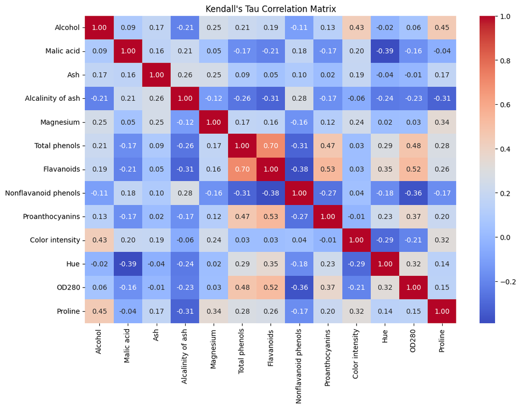

```python
#!# BEGIN SOLUTION
# Compute the Kendall's Tau correlation matrix
correlation_matrix = df.corr(method='kendall')
#!# END SOLUTION

# Plot the heatmap
plt.figure(figsize=(12, 8))
sns.heatmap(correlation_matrix, annot=True, cmap='coolwarm', fmt=".2f", cbar=True)
plt.title("Kendall's Tau Correlation Matrix")
plt.show()
```

Now we want to use MIC as the correlation. There are many way to code it. Here we start by using mutual_info_score from sklearn, which is more compatible for most of Python version.

Let's finish the function to compute MIC.

```python
from sklearn.metrics import mutual_info_score
from itertools import combinations

def compute_mic(data):
    """
    Compute the Maximal Information Coefficient (MIC) for each pair of features in the dataset.

    Parameters:
    - data: DataFrame containing the dataset.

    Returns:
    - mic_results: DataFrame with feature pairs and their MIC values.
    """
    def calculate_mutual_information(x, y, bins_x, bins_y):
        """
        Calculate mutual information for two variables given specific binning.
        """
        # Digitize the data into specified bins
        x_binned = np.digitize(x, bins=np.linspace(min(x), max(x), bins_x))
        y_binned = np.digitize(y, bins=np.linspace(min(y), max(y), bins_y))

        # Compute mutual information
        return mutual_info_score(x_binned, y_binned)

    feature_pairs = list(combinations(data.columns, 2))  # All possible pairs of features
    mic_results = []

    # Bin range from 2 to int(df.shape[0]**0.6)
    max_bins = int(data.shape[0] ** 0.6)

    for feature_x, feature_y in feature_pairs:
        x = data[feature_x].values
        y = data[feature_y].values

        mic_value = 0  # Initialize the maximum MIC value for this pair

        # Exploring all possible grids
        for bins_x in range(2, max_bins + 1):
            for bins_y in range(2, max_bins + 1):
                # Compute mutual information for the current grid
                mi = calculate_mutual_information(x, y, bins_x, bins_y)

                # Normalize mutual information by log_2(min(bins_x, bins_y))
                # MIC is maximum of the normalized mutual information values

                #!# BEGIN SOLUTION
                # Compute MIC from mutual information
                normalization_factor = np.log2(min(bins_x, bins_y))
                normalized_mi = mi / normalization_factor
                #!# END SOLUTION

                # Update the maximum MIC value
                mic_value = max(mic_value, normalized_mi)

        # Store the results
        mic_results.append({
            "Feature X": feature_x,
            "Feature Y": feature_y,
            "MIC": mic_value
        })

    # Convert results to a DataFrame
    mic_results = pd.DataFrame(mic_results)
    return mic_results

# Load the dataset
data = pd.read_csv('sem4_portfolio_8_data_wine_italy.csv', header=0)
df = pd.DataFrame(data).iloc[:, 1:]  # Select all columns except the index

#!# BEGIN SOLUTION
# Compute MIC for all pairs of features
mic_results = compute_mic(df)
#!# END SOLUTION

# Display the top 10 feature pairs by MIC value
mic_results = mic_results.sort_values(by="MIC", ascending=False)
print(mic_results.head(10))
```

```
               Feature X        Feature Y       MIC
50         Total phenols       Flavanoids  0.316980
61            Flavanoids            OD280  0.289887
75                   Hue            OD280  0.238118
66  Nonflavanoid phenols            OD280  0.236049
55         Total phenols            OD280  0.233515
58            Flavanoids  Proanthocyanins  0.223213
70       Proanthocyanins            OD280  0.222603
59            Flavanoids  Color intensity  0.217225
62            Flavanoids          Proline  0.215795
8                Alcohol  Color intensity  0.215747
```

And compute the heatmap

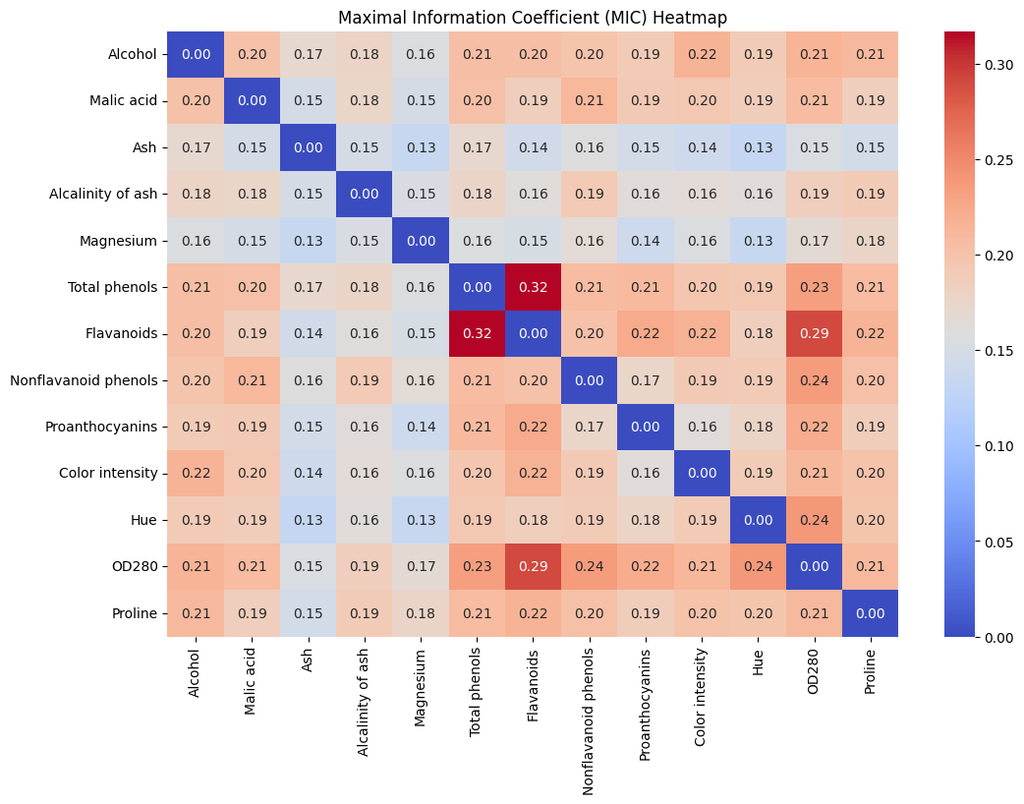

```python
def plot_mic_heatmap(mic_results, data):
    """
    Plot a heatmap for MIC values between all pairs of features.

    Parameters:
    - mic_results: DataFrame containing MIC values for feature pairs.
    - data: Original dataset for extracting feature names.
    """
    # Initialize an empty MIC matrix
    features = data.columns
    mic_matrix = pd.DataFrame(np.zeros((len(features), len(features))), index=features, columns=features)

    # Fill the MIC matrix with computed values
    for _, row in mic_results.iterrows():
        mic_matrix.loc[row['Feature X'], row['Feature Y']] = row['MIC']
        mic_matrix.loc[row['Feature Y'], row['Feature X']] = row['MIC']  # Fill symmetric value

    # Plot the heatmap
    plt.figure(figsize=(12, 8))
    sns.heatmap(mic_matrix, annot=True, cmap='coolwarm', fmt=".2f", cbar=True)
    plt.title("Maximal Information Coefficient (MIC) Heatmap")
    plt.show()

# Example Usage
plot_mic_heatmap(mic_results, df)
```

## **2.** Clustering

Make some preparation like defining plotting function, importing the dataset, etc.

```python
from sklearn.cluster import KMeans
from sklearn.decomposition import PCA
from sklearn.cluster import AgglomerativeClustering
from sklearn.cluster import DBSCAN
from scipy.spatial.distance import pdist, squareform
from scipy.cluster.hierarchy import linkage
```

```python
# Function to plot true labels and cluster labels side by side
# X need to be list or numpy array
def plot_true_vs_clustered(X, true_labels, cluster_labels, cluster_centers=None):
    fig, axs = plt.subplots(1, 2, figsize=(16, 6))

    # Plot true labels
    axs[0].set_title('True Labels')
    unique_true_labels = set(true_labels)
    colors_true = plt.cm.rainbow(np.linspace(0, 1, len(unique_true_labels)))
    for k, col in zip(unique_true_labels, colors_true):
        class_member_mask = (true_labels == k)
        xy = X[class_member_mask]
        axs[0].plot(xy[:, 0], xy[:, 1], 'o', markerfacecolor=col, markeredgecolor='k', markersize=10)
        axs[0].set_xlabel("PCA 0")
        axs[0].set_ylabel("PCA 1")

    # Plot clustered labels
    axs[1].set_title('Clustered Labels')
    unique_cluster_labels = set(cluster_labels)
    colors_cluster = plt.cm.rainbow(np.linspace(0, 1, len(unique_cluster_labels)))
    for k, col in zip(unique_cluster_labels, colors_cluster):
        class_member_mask = (cluster_labels == k)
        xy = X[class_member_mask]
        axs[1].plot(xy[:, 0], xy[:, 1], 'o', markerfacecolor=col, markeredgecolor='k', markersize=10, label='Cluster '+str(k))
        axs[1].set_xlabel("PCA 0")
        axs[1].set_ylabel("PCA 1")
        axs[1].legend()
        if cluster_centers is not None and k != -1:
            center = cluster_centers[k]
            axs[1].plot(center[0], center[1], 'o', markerfacecolor=col, markeredgecolor='k', markeredgewidth=2, markersize=14)

    plt.show()

def plot_mean_all_feature(X, cluster_labels):
    # Calculate means and standard deviations by cluster
    columns = list(X.columns)
    clusters = np.unique(cluster_labels)
    mean_ratios = []
    std_devs = []

    for cluster in clusters:
        cluster_data = X[cluster_labels == cluster]
        means = cluster_data.mean(axis=0)
        total_means = X.mean(axis=0)
        stds = cluster_data.std(axis=0,ddof=1)
        total_std = X.std(axis=0,ddof=1)
        mean_ratios.append((means - total_means)/total_std)  # Normalize
        std_devs.append(stds/total_std)

    # Plot
    x = np.arange(len(columns))
    width = 0.1  # Adjust as needed
    colors = ['red', 'green', 'blue', 'black', 'yellow', 'orange', 'purple', 'pink', 'brown', 'gray']

    plt.figure(figsize=(12, 6))
    for i, cluster in enumerate(clusters):
        plt.errorbar(
            x + i * width,
            mean_ratios[i],
            yerr=std_devs[i],
            fmt='o',
            label=f'Cluster {cluster}',
            color=colors[i]
        )

    plt.xticks(x, columns, rotation=45, ha='right')
    plt.ylabel('Normalized Mean (with Std Dev)')
    #plt.ylim(-5,5)
    plt.title('Cluster Features Analysis')
    plt.legend(loc="upper center")
    plt.tight_layout()
    plt.show()

# Function to plot the first two columns
def plot_clustered(X, cluster_centers):
    X = np.asarray(X)
    nfeature = X.shape[-1]
    if nfeature > 2:
        X = X[:,:2]
    if nfeature < 2:
        print("Error")
    # Plot clustered labels
    unique_cluster_labels = set(cluster_labels)
    colors_cluster = plt.cm.rainbow(np.linspace(0, 1, len(unique_cluster_labels)))
    for k, col in zip(unique_cluster_labels, colors_cluster):
        class_member_mask = (cluster_labels == k)
        xy = X[class_member_mask]
        plt.plot(xy[:, 0], xy[:, 1], 'o', markerfacecolor=col)
    plt.show()
```

Load the data and make a PCA for plotting

```python
# Load the CSV file without header first
data = pd.read_csv('sem4_portfolio_8_data_wine_italy.csv',header=0)
true_labels = np.asarray([1]*59 + [2]*71 + [3]*48)  # Adjust numbers if needed
print(data.info)

# Select desired columns and apply the algorithm
X = data.iloc[:, 1:]
# We want the top 2 components for the plot
# And apply PCA transformation
pca = PCA(n_components=2)
X_pca = pca.fit_transform(X)
```

```
<bound method DataFrame.info of       id  Alcohol  Malic acid   Ash  Alcalinity of ash  Magnesium  \
0      1    14.23        1.71  2.43               15.6        127
1      2    13.20        1.78  2.14               11.2        100
2      3    13.16        2.36  2.67               18.6        101
3      4    14.37        1.95  2.50               16.8        113
4      5    13.24        2.59  2.87               21.0        118
..   ...      ...         ...   ...                ...        ...
173  174    13.71        5.65  2.45               20.5         95
174  175    13.40        3.91  2.48               23.0        102
175  176    13.27        4.28  2.26               20.0        120
176  177    13.17        2.59  2.37               20.0        120
177  178    14.13        4.10  2.74               24.5         96

     Total phenols  Flavanoids  Nonflavanoid phenols  Proanthocyanins  \
0             2.80        3.06                  0.28             2.29
```

[output cut: 25 more lines]

Let's apply a kmean

```
Algorithm found 3 clusters.
Points per cluster: Counter({2: 69, 0: 62, 1: 47})
True labels have 3 clusters.
Points per cluster for true labels: Counter({2: 71, 1: 59, 3: 48})
Silhouette Score: 0.571138193786884
```

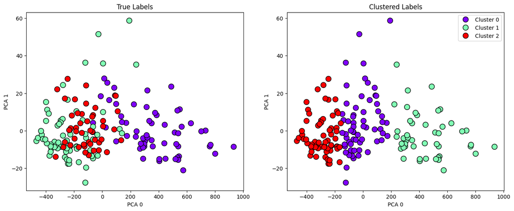

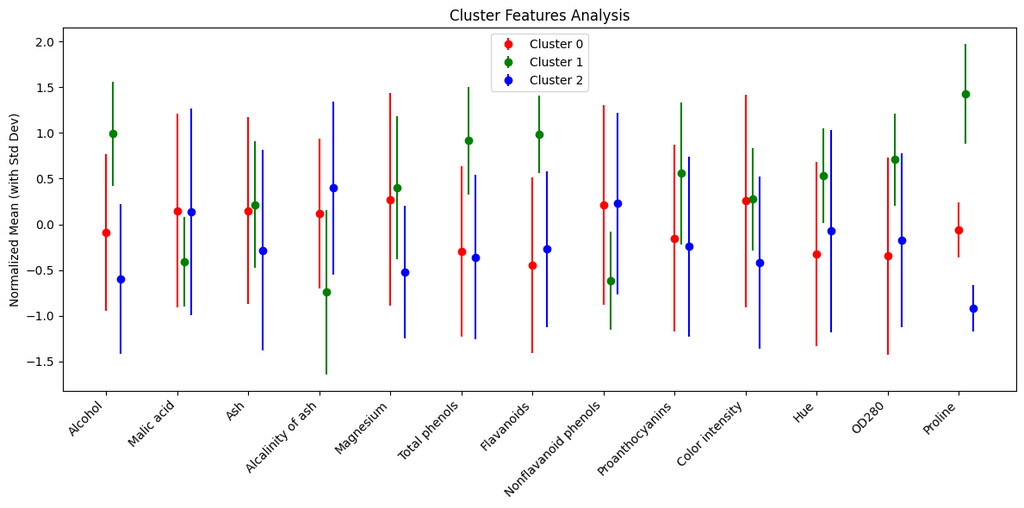

```python
#!# BEGIN SOLUTION
# Apply a kmean clustering of 3 clusters
kmeans = KMeans(n_clusters=3, random_state=42, n_init=10)
cluster_labels = kmeans.fit_predict(X_pca)
#!# END SOLUTION

### The algorithm end here, the following code calculates the number of each clusters and plots it
cluster_counts = Counter(cluster_labels)
print(f"Algorithm found {len(cluster_counts)} clusters.")
print("Points per cluster:", cluster_counts)
true_label_counts = Counter(true_labels)
print(f"True labels have {len(true_label_counts)} clusters.")
print("Points per cluster for true labels:", true_label_counts)

# Silhouette Score
print(f"Silhouette Score: {silhouette_score(X, cluster_labels)}\n")

# Plot true labels vs. clustering results
# For plotting the first two column and your clusters result: plot_clustered(X, cluster_labels)
plot_true_vs_clustered(X_pca, true_labels, cluster_labels)
plot_mean_all_feature(X,cluster_labels)
```

Let's apply a Ward clustering

```
Algorithm found 3 clusters.
Points per cluster: Counter({1: 72, 2: 58, 0: 48})
True labels have 3 clusters.
Points per cluster for true labels: Counter({2: 71, 1: 59, 3: 48})
Silhouette Score: 0.5644796401732071
```

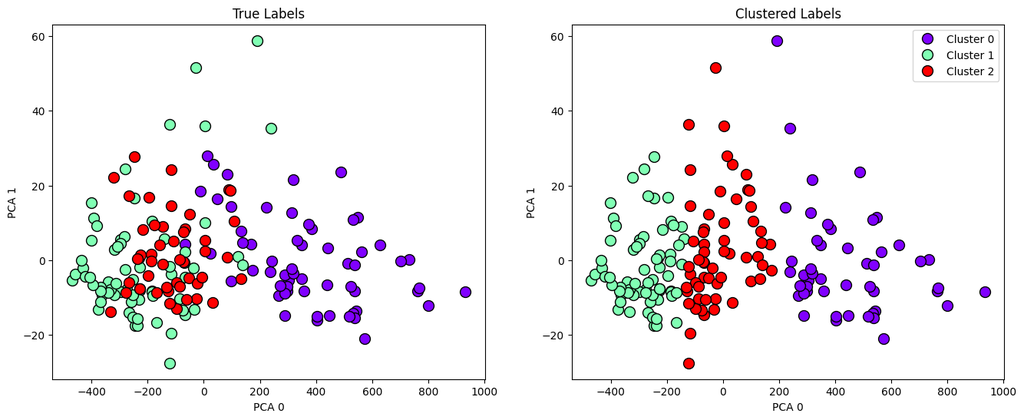

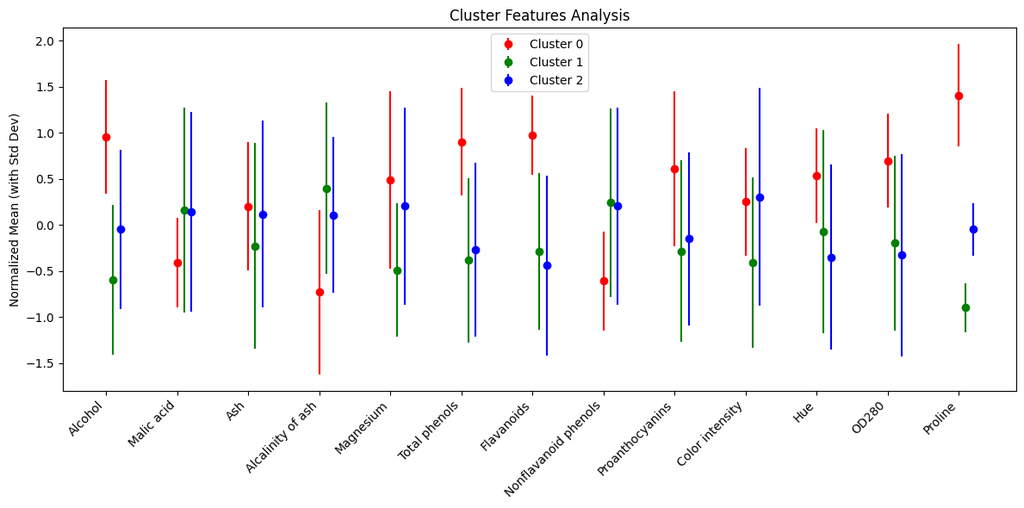

```python
#!# BEGIN SOLUTION
# Apply a Ward clustering of 3 clusters
agg_cluster = AgglomerativeClustering(n_clusters=3, linkage='ward')
cluster_labels = agg_cluster.fit_predict(X)
#!# END SOLUTION

### The algorithm end here, the following code calculates the number of each clusters and plots it
cluster_counts = Counter(cluster_labels)
print(f"Algorithm found {len(cluster_counts)} clusters.")
print("Points per cluster:", cluster_counts)
true_label_counts = Counter(true_labels)
print(f"True labels have {len(true_label_counts)} clusters.")
print("Points per cluster for true labels:", true_label_counts)

# Silhouette Score
print(f"Silhouette Score: {silhouette_score(X, cluster_labels)}\n")

# Plot true labels vs. clustering results
# For plotting the first two column and your clusters result: plot_clustered(X, cluster_labels)
plot_true_vs_clustered(X_pca, true_labels, cluster_labels)
plot_mean_all_feature(X,cluster_labels)
```

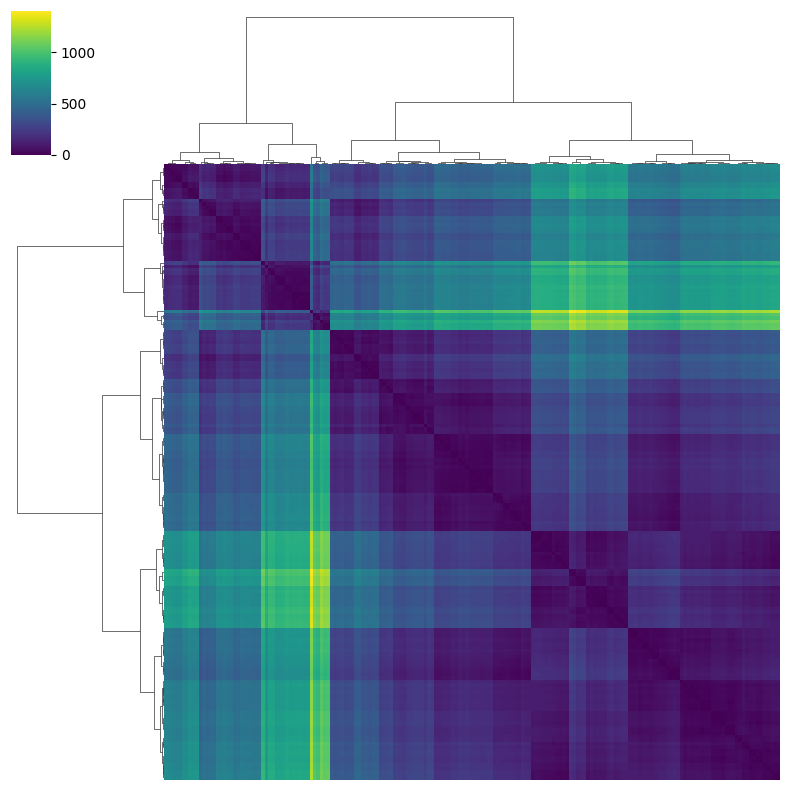

```python
# Convert the true labels to a color palette
lut = sns.color_palette('tab10', n_colors=len(set(true_labels)))
row_colors = pd.Series(true_labels).map(dict(zip(range(len(set(true_labels))), lut)))

# Perform hierarchical clustering
pairwise_dists = pdist(X)
linkage_matrix = linkage(pairwise_dists, method="ward")

# Compute the distance matrix for plotting
distance_matrix = squareform(pairwise_dists)

# Heatmap of the distance matrix with the previous clustering tree
sns.clustermap(distance_matrix, row_cluster=True, col_cluster=True,
               row_linkage=linkage_matrix, col_linkage=linkage_matrix,
               figsize=(8, 8), cmap='viridis', xticklabels=False, yticklabels=False)

plt.show()
```

Let's apply a DBSCAN

```
Algorithm found 4 clusters.
Points per cluster: Counter({1: 130, 0: 22, -1: 13, 2: 13})
True labels have 3 clusters.
Points per cluster for true labels: Counter({2: 71, 1: 59, 3: 48})
Silhouette Score: 0.51917076299868
```

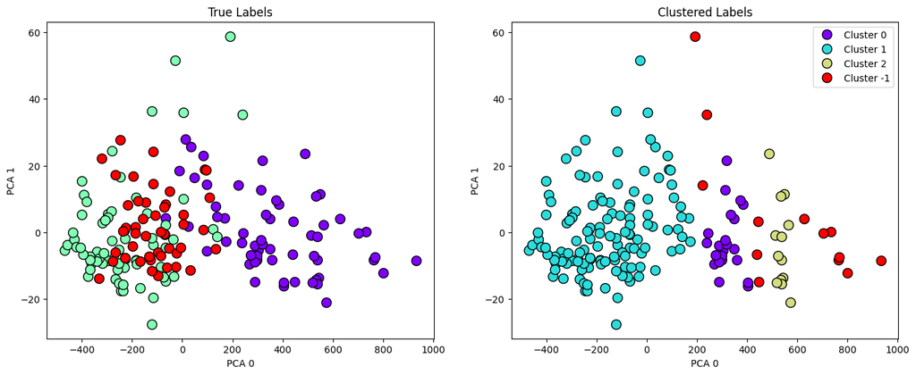

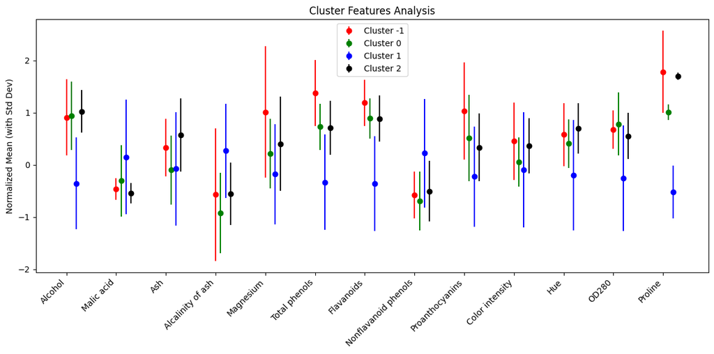

```python
#!# BEGIN SOLUTION
# Apply a DBSCAN

dbscan = DBSCAN(eps=50, min_samples=10, metric='euclidean')
cluster_labels = dbscan.fit_predict(X)
#!# END SOLUTION

### The algorithm end here, the following code calculates the number of each clusters and plots it
cluster_counts = Counter(cluster_labels)
print(f"Algorithm found {len(cluster_counts)} clusters.")
print("Points per cluster:", cluster_counts)
true_label_counts = Counter(true_labels)
print(f"True labels have {len(true_label_counts)} clusters.")
print("Points per cluster for true labels:", true_label_counts)

# Silhouette Score
print(f"Silhouette Score: {silhouette_score(X, cluster_labels)}\n")

# Plot true labels vs. clustering results
# For plotting the first two column and your clusters result: plot_clustered(X, cluster_labels)
plot_true_vs_clustered(X_pca, true_labels, cluster_labels)
plot_mean_all_feature(X,cluster_labels)
```

## **3.** Propensity Score Matching

Let's compute the PSM using the most common way.

You may need to install psmpy !pip install psmpy

```python
import pandas as pd
from psmpy.psmpy import PsmPy
```

Import the data

```python
# Load the dataset
url = "https://archive.ics.uci.edu/ml/machine-learning-databases/adult/adult.data"
columns = [
    'Age', 'Workclass', 'fnlwgt', 'Education', 'Education-Num', 'Marital-Status',
    'Occupation', 'Relationship', 'Race', 'Sex', 'Capital-Gain', 'Capital-Loss', 'Hours-per-week', 'Native-Country', 'Income'
]
df = pd.read_csv(url, header=None, names=columns, na_values=[' ?'], skipinitialspace=True)

# as an example, we take only a subset of 1000 samples to keep it fast
df = df.sample(n=1000, random_state=42)

# Prepare the dataset, we set Female = 1 is the "treatment"
df = df.dropna()  # Drop rows with missing values
df['Income'] = df['Income'].map({'<=50K': 0, '>50K': 1})  # Income >50K as outcome
df['Sex'] = df['Sex'].map({'Male': 0, 'Female': 1})  # Female = 1 (treatment)
df['Race'] = df['Race'].apply(lambda x: 1 if x in ['White'] else 0)

# Keep only the specified columns
df = df[['Income', 'Education-Num', 'Age', 'Hours-per-week', 'Race', 'Sex']]

# Add an index column
df = df.reset_index(drop=True)
df['Index'] = df.index
```

```python
df
```

|  | Income | Education-Num | Age | Hours-per-week | Race | Sex | Index |
| --- | --- | --- | --- | --- | --- | --- | --- |
| 0 | 0 | 10 | 27 | 38 | 1 | 1 | 0 |
| 1 | 0 | 9 | 45 | 40 | 1 | 1 | 1 |
| 2 | 1 | 13 | 29 | 55 | 0 | 0 | 2 |
| 3 | 0 | 13 | 30 | 40 | 1 | 1 | 3 |
| 4 | 0 | 10 | 29 | 50 | 1 | 0 | 4 |
| ... | ... | ... | ... | ... | ... | ... | ... |
| 995 | 1 | 13 | 35 | 35 | 1 | 0 | 995 |
| 996 | 0 | 10 | 21 | 40 | 0 | 0 | 996 |
| 997 | 0 | 7 | 21 | 40 | 1 | 0 | 997 |
| 998 | 1 | 16 | 42 | 60 | 1 | 0 | 998 |
| 999 | 0 | 10 | 24 | 40 | 1 | 1 | 999 |

1000 rows × 7 columns

We can use psm.logistic_ps to compute the propensity Scores and use psm.predicted_data to get the result

```python
psm = PsmPy(
    df,
    treatment='Sex',  # The treatment variable (being female), 1 is being treated
    indx='Index'  # The index of samples
)

# Step 4: Calculate Propensity Scores
psm.logistic_ps()
print(set(psm.predicted_data['propensity_score']))
```

```
{0.6385778368180315, 0.7450267769659344, 0.6522844045076699, 0.6798292643750088, 0.7164425005608024, 0.5233653678383376, 0.5562516130066024, 0.502659823796102, 0.82729518908726, 0.6156171806686226, 0.7540346058352441, 0.5742346576755716, 0.4476662498136951, 0.5864184176559422, 0.50051524436946, 0.69…
```

Check for Common Support

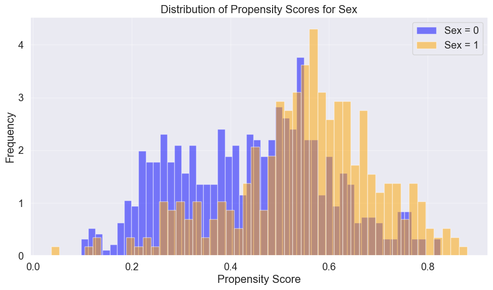

```python
# Separate propensity scores for each group
sex_0_scores = psm.predicted_data[psm.predicted_data['Sex'] == 0]['propensity_score']
sex_1_scores = psm.predicted_data[psm.predicted_data['Sex'] == 1]['propensity_score']

# Plot the distributions
plt.figure(figsize=(10, 6))
plt.hist(sex_0_scores, bins=50, alpha=0.5, label='Sex = 0', color='blue', density=True)
plt.hist(sex_1_scores, bins=50, alpha=0.5, label='Sex = 1', color='orange', density=True)

# Add labels, title, and legend
plt.title('Distribution of Propensity Scores for Sex')
plt.xlabel('Propensity Score')
plt.ylabel('Frequency')
plt.legend()
plt.grid(alpha=0.4)
plt.tight_layout()

# Display the plot
plt.show()
```

Matching procedure of nearest neighbor

```python
def nearest_neighbor_matching(data, treatment_col, propensity_col):
    """
    Perform Nearest Neighbor Matching without replacement.

    Parameters:
    - data: DataFrame containing the data.
    - treatment_col: Name of the column indicating treatment (e.g., 'Sex').
    - propensity_col: Name of the column with propensity scores (e.g., 'propensity_score').

    Returns:
    - matched_pairs: List of (treated_index, control_index) tuples representing matched pairs.
    """
    # Separate treated and untreated units
    treated = data[data[treatment_col] == 1].copy()
    control = data[data[treatment_col] == 0].copy()

    # Create an empty list to store matched pairs
    matched_pairs = []

    # Loop through each treated unit
    for treated_idx, treated_row in treated.iterrows():
        # Calculate the absolute differences in propensity scores with control units
        control['distance'] = np.abs(control[propensity_col] - treated_row[propensity_col])

        # Find the control unit with the smallest distance
        closest_control_idx = control['distance'].idxmin()

        # Append the matched pair (treated index, control index)
        matched_pairs.append((treated_idx, closest_control_idx))

        # Remove the matched control unit from the pool (without replacement)
        control = control.drop(index=closest_control_idx)

    return matched_pairs
```

```python
#!# BEGIN SOLUTION
matched_pairs = nearest_neighbor_matching(data=psm.predicted_data,
                                          treatment_col='Sex',
                                          propensity_col='propensity_score')

# Display the matched pairs
print("Matched Pairs (treated_index, control_index):")
print(len(matched_pairs))
```

```
Matched Pairs (treated_index, control_index):
344
```

Assess Covariate Balance by SMD

```python
def calculate_smd(df, matched_pairs, covariates):
    """
    Calculate Standardized Mean Differences (SMD) for covariates between treated and control groups.

    Parameters:
    - df: The original DataFrame containing the data.
    - matched_pairs: A list of tuples (treated_index, control_index) representing matched pairs.
    - covariates: A list of column names (covariates) to calculate SMD for.

    Returns:
    - smd_results: A dictionary with covariates as keys and their corresponding SMDs as values.
    """
    # Extract matched data
    treated_indices, control_indices = zip(*matched_pairs)
    treated_group = df.loc[list(treated_indices)]
    control_group = df.loc[list(control_indices)]

    smd_results = {}

    for covariate in covariates:
        # Calculate means and standard deviations
        treated_mean = treated_group[covariate].mean()
        control_mean = control_group[covariate].mean()
        treated_std = treated_group[covariate].std()
        control_std = control_group[covariate].std()

        # Pooled standard deviation
        pooled_std = np.sqrt(
            ((len(treated_group) - 1) * treated_std ** 2 + (len(control_group) - 1) * control_std ** 2)
            / (len(treated_group) + len(control_group) - 2)
        )

        # Calculate SMD
        smd = abs(treated_mean - control_mean) / pooled_std
        smd_results[covariate] = smd

    return smd_results
```

```python
#!# BEGIN SOLUTION
# Choose covariates as you like and Calculate SMDs by using the above function
covariates = ['Income', 'Age', 'Education-Num', 'Race']
smd_results = calculate_smd(df=psm.predicted_data, matched_pairs=matched_pairs, covariates=covariates)
#!# END SOLUTION

# Display Results
print("Standardized Mean Differences (SMD):")
for covariate, smd in smd_results.items():
    print(f"{covariate}: {smd:.4f}")
```

```
Standardized Mean Differences (SMD):
Income: 0.0257
Age: 0.0549
Education-Num: 0.0226
Race: 0.0545
```

Calculate ATT as the final result

```python
def calculate_att(df, matched_pairs, outcome_col):
    """
    Calculate the Average Treatment Effect on the Treated (ATT).

    Parameters:
    - df: The original DataFrame containing the data.
    - matched_pairs: A list of tuples (treated_index, control_index) representing matched pairs.
    - outcome_col: The name of the outcome variable column (e.g., 'Hours-per-week').

    Returns:
    - att: The calculated ATT value.
    """
    # Extract treated and control indices from matched pairs
    treated_indices, control_indices = zip(*matched_pairs)

    # Extract the outcome values for treated and control groups
    treated_outcomes = df.loc[list(treated_indices), outcome_col]
    control_outcomes = df.loc[list(control_indices), outcome_col]

    # Compute ATT as the average difference in outcomes
    att = (treated_outcomes.values - control_outcomes.values).mean()

    return att

#!# BEGIN SOLUTION
# Use the above function to compute ATT
outcome_col = 'Hours-per-week'
att = calculate_att(psm.predicted_data, matched_pairs, outcome_col)
#!# END SOLUTION

# Display the result
print(f"Average Treatment Effect on the Treated (ATT): {att:.4f}")
```

```
Average Treatment Effect on the Treated (ATT): -1.8140
```

```python
def calculate_att_binary(df, matched_pairs, outcome_col):
    """
    Calculate ATT for binary outcome variables.

    Parameters:
    - df: The original DataFrame containing the data.
    - matched_pairs: A list of tuples (treated_index, control_index) representing matched pairs.
    - outcome_col: The name of the binary outcome variable column.

    Returns:
    - att: The calculated ATT value.
    """
    # Extract treated and control indices from matched pairs
    treated_indices, control_indices = zip(*matched_pairs)

    # Extract the outcome values for treated and control groups
    treated_outcomes = df.loc[list(treated_indices), outcome_col]
    control_outcomes = df.loc[list(control_indices), outcome_col]

    # Compute proportions
    treated_proportion = treated_outcomes.mean()
    control_proportion = control_outcomes.mean()

    # Calculate ATT as the difference in proportions
    att = treated_proportion - control_proportion

    return att

# Example
# Just for indication, we should not change variable in the last step
binary_outcome_col = 'Race'
att_binary = calculate_att_binary(df=psm.predicted_data, matched_pairs=matched_pairs, outcome_col=binary_outcome_col)

# Display the result
print(f"Average Treatment Effect on the Treated (ATT) for Binary Outcome: {att_binary:.4f}")
```

```
Average Treatment Effect on the Treated (ATT) for Binary Outcome: -0.0203
```

# SUMMATIVE ASSESSMENT

Now pick a dataset of your choice. Please ensure your dataset is a csv file under 100MB named sem4_portfolio_8_data_custom.csv

Apply at least one correlation method, one clustering method, and explain all your results Use PSM to check causality of some features. You can use multiple datasets or use toy datasets for this notebook.

Note: Your PSM doesn't need to have great results at the end. But you need to be able to intepret that.

```python
custom_data_path = "sem4_portfolio_8_data_custom.csv"
custom_df = pd.read_csv(custom_data_path)
```

The Mental Health Diagnosis and Treatment Monitoring dataset contains 500 rows representing real-world mental health diagnoses, treatment plans, and outcomes. It includes patient demographics, symptom severity, medication, therapy types, and progress tracking.

Patient ID: Unique identifier.  
Age: Age of the patient.  
Gender: Male or Female.  
Diagnosis: Mental health condition (e.g., Anxiety, Depression).  
Symptom Severity (1-10): Severity of symptoms.  
Mood Score (1-10): Mood rating during treatment.  
Sleep Quality (1-10): Patient-reported sleep quality.  
Physical Activity: Hours per week of activity.  
Medication: Medications prescribed (e.g., SSRIs, Antidepressants).  
Therapy Type: Type of therapy (e.g., CBT, DBT).  
Treatment Start Date: Date treatment started.  
Treatment Duration: Duration of treatment in weeks.  
Stress Level (1-10): Patient's stress level.  
Outcome: Treatment outcome (e.g., Improved, Deteriorated).  
Treatment Progress (1-10): Progress made during treatment.  
AI-Detected Emotional State: AI-detected emotional state (e.g., Happy, Anxious).  
Adherence to Treatment (%): Percentage of adherence to treatment plan.

### We want to clustering for diagnosis in this assignment

#### Part_1: Data Preprocessing

```python
# Display the dataset to have a brief understanding

print(custom_df.shape)

display(custom_df.head())
```

```
(500, 17)
```

|  | Patient ID | Age | Gender | Diagnosis | Symptom Severity (1-10) | Mood Score (1-10) | Sleep Quality (1-10) | Physical Activity (hrs/week) | Medication | Therapy Type | Treatment Start Date | Treatment Duration (weeks) | Stress Level (1-10) | Outcome | Treatment Progress (1-10) | AI-Detected Emotional State | Adherence to Treatment (%) |
| --- | --- | --- | --- | --- | --- | --- | --- | --- | --- | --- | --- | --- | --- | --- | --- | --- | --- |
| 0 | 1 | 43 | Female | Major Depressive Disorder | 10 | 5 | 8 | 5 | Mood Stabilizers | Interpersonal Therapy | 2024-01-25 | 11 | 9 | Deteriorated | 7 | Anxious | 66 |
| 1 | 2 | 40 | Female | Major Depressive Disorder | 9 | 5 | 4 | 7 | Antipsychotics | Interpersonal Therapy | 2024-02-27 | 11 | 7 | No Change | 7 | Neutral | 78 |
| 2 | 3 | 55 | Female | Major Depressive Disorder | 6 | 3 | 4 | 3 | SSRIs | Mindfulness-Based Therapy | 2024-03-20 | 14 | 7 | Deteriorated | 5 | Happy | 62 |
| 3 | 4 | 34 | Female | Major Depressive Disorder | 6 | 3 | 6 | 5 | SSRIs | Mindfulness-Based Therapy | 2024-03-29 | 8 | 8 | Deteriorated | 10 | Excited | 72 |
| 4 | 5 | 52 | Male | Panic Disorder | 7 | 6 | 6 | 8 | Anxiolytics | Interpersonal Therapy | 2024-03-18 | 12 | 5 | Deteriorated | 6 | Excited | 63 |

```python
# Represent the string with integer
mapping = {
           'generalized anxiety': 0,
           'major depressive disorder': 1,
           'bipolar disorder': 2,
           'panic disorder':3
           }

custom_df['Diagnosis']  = custom_df['Diagnosis'].str.strip().str.lower().map(mapping)

mapping = {'female': 0, 'male': 1}

custom_df['Gender']  = custom_df['Gender'].str.strip().str.lower().map(mapping)

# Delete irrelevant columns
custom_df = custom_df.drop(columns=['Patient ID','Treatment Start Date'])

# Delete all "Other" values in columns
custom_df = custom_df[custom_df['Medication'] != 'Other']
custom_df = custom_df[custom_df['AI-Detected Emotional State'] != 'Other']

# We only consider if the outcome is improved
mapping = {'improved': 1, 'deteriorated': 0, 'no Change': 0}
custom_df['Outcome'] = custom_df['Outcome'].str.strip().str.lower().map(mapping)

custom_df = custom_df.dropna()
```

```python
print(custom_df)
```

```
     Age  Gender  Diagnosis  Symptom Severity (1-10)  Mood Score (1-10)  \
0     43       0          1                       10                  5
2     55       0          1                        6                  3
3     34       0          1                        6                  3
4     52       1          3                        7                  6
6     59       1          0                        6                  6
..   ...     ...        ...                      ...                ...
495   24       1          0                       10                  4
496   22       1          3                        5                  6
497   23       1          1                        7                  3
498   48       1          2                        9                  4
499   58       1          2                        5                  7

     Sleep Quality (1-10)  Physical Activity (hrs/week)        Medication  \
0                       8                             5  Mood Stabilizers
```

[output cut: 51 more lines]

```python
# One-hot code the categorical variables
columns_to_code = ['Medication','AI-Detected Emotional State','Therapy Type']
custom_df = pd.get_dummies(custom_df, columns=columns_to_code).astype('int')
```

```python
print(custom_df['Diagnosis'].value_counts())
```

```
Diagnosis
0    90
2    90
3    85
1    76
Name: count, dtype: int64
```

```python
# Give true labels
true_labels = np.asarray([0]*90 + [1]*76 + [2]*90 + [3]*85)
```

#### Part_2: Kendall's Tau for Correlation

Compute the Kendall's Tau as the correlation using dataFrame.corr.

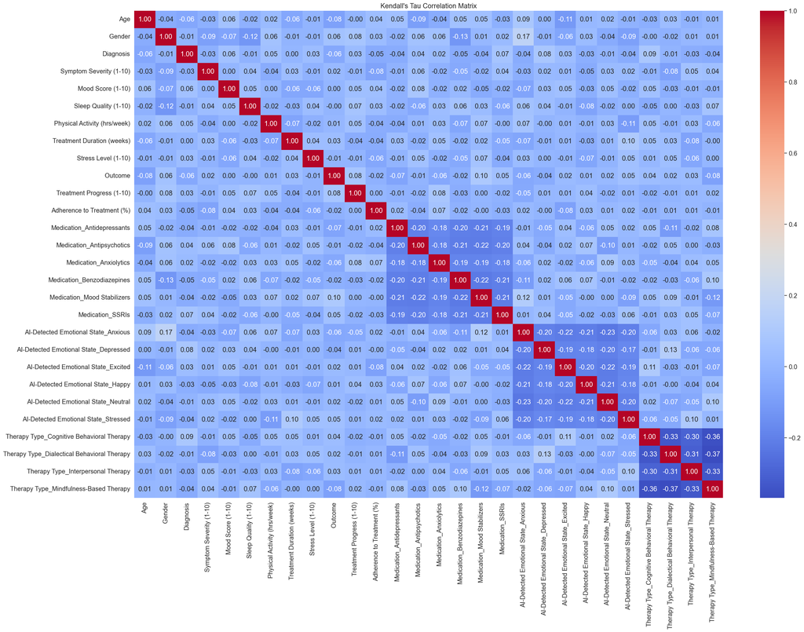

```python
# Compute the Kendall's Tau correlation matrix
correlation_matrix = custom_df.corr(method='kendall')

# Plot the heatmap
plt.figure(figsize=(30, 20))
sns.heatmap(correlation_matrix, annot=True, cmap='coolwarm', fmt=".2f", cbar=True)
plt.title("Kendall's Tau Correlation Matrix")
plt.show()
```

Correlations: Most variables show negligible associations (|τ| ≤ 0.10).

#### Part_3: KMean for Clustering

```python
from sklearn.cluster import KMeans
from sklearn.decomposition import PCA
from sklearn.cluster import AgglomerativeClustering
from sklearn.cluster import DBSCAN
from scipy.spatial.distance import pdist, squareform
from scipy.cluster.hierarchy import linkage
```

```python
# Function to plot true labels and cluster labels side by side
# X need to be list or numpy array
def plot_true_vs_clustered(X, true_labels, cluster_labels, cluster_centers=None):
    fig, axs = plt.subplots(1, 2, figsize=(16, 6))

    # Plot true labels
    axs[0].set_title('True Labels')
    unique_true_labels = set(true_labels)
    colors_true = plt.cm.rainbow(np.linspace(0, 1, len(unique_true_labels)))
    for k, col in zip(unique_true_labels, colors_true):
        class_member_mask = (true_labels == k)
        xy = X[class_member_mask]
        axs[0].plot(xy[:, 0], xy[:, 1], 'o', markerfacecolor=col, markeredgecolor='k', markersize=10)
        axs[0].set_xlabel("PCA 0")
        axs[0].set_ylabel("PCA 1")

    # Plot clustered labels
    axs[1].set_title('Clustered Labels')
    unique_cluster_labels = set(cluster_labels)
    colors_cluster = plt.cm.rainbow(np.linspace(0, 1, len(unique_cluster_labels)))
    for k, col in zip(unique_cluster_labels, colors_cluster):
        class_member_mask = (cluster_labels == k)
        xy = X[class_member_mask]
        axs[1].plot(xy[:, 0], xy[:, 1], 'o', markerfacecolor=col, markeredgecolor='k', markersize=10, label='Cluster '+str(k))
        axs[1].set_xlabel("PCA 0")
        axs[1].set_ylabel("PCA 1")
        axs[1].legend()
        if cluster_centers is not None and k != -1:
            center = cluster_centers[k]
            axs[1].plot(center[0], center[1], 'o', markerfacecolor=col, markeredgecolor='k', markeredgewidth=2, markersize=14)

    plt.show()

def plot_mean_all_feature(X, cluster_labels):
    # Calculate means and standard deviations by cluster
    columns = list(X.columns)
    clusters = np.unique(cluster_labels)
    mean_ratios = []
    std_devs = []

    for cluster in clusters:
        cluster_data = X[cluster_labels == cluster]
        means = cluster_data.mean(axis=0)
        total_means = X.mean(axis=0)
        stds = cluster_data.std(axis=0,ddof=1)
        total_std = X.std(axis=0,ddof=1)
        mean_ratios.append((means - total_means)/total_std)  # Normalize
        std_devs.append(stds/total_std)

    # Plot
    x = np.arange(len(columns))
    width = 0.1  # Adjust as needed
    colors = ['red', 'green', 'blue', 'black', 'yellow', 'orange', 'purple', 'pink', 'brown', 'gray']

    plt.figure(figsize=(12, 6))
    for i, cluster in enumerate(clusters):
        plt.errorbar(
            x + i * width,
            mean_ratios[i],
            yerr=std_devs[i],
            fmt='o',
            label=f'Cluster {cluster}',
            color=colors[i]
        )

    plt.xticks(x, columns, rotation=45, ha='right')
    plt.ylabel('Normalized Mean (with Std Dev)')
    #plt.ylim(-5,5)
    plt.title('Cluster Features Analysis')
    plt.legend(loc="upper center")
    plt.tight_layout()
    plt.show()

# Function to plot the first two columns
def plot_clustered(X, cluster_centers):
    X = np.asarray(X)
    nfeature = X.shape[-1]
    if nfeature > 2:
        X = X[:,:2]
    if nfeature < 2:
        print("Error")
    # Plot clustered labels
    unique_cluster_labels = set(cluster_labels)
    colors_cluster = plt.cm.rainbow(np.linspace(0, 1, len(unique_cluster_labels)))
    for k, col in zip(unique_cluster_labels, colors_cluster):
        class_member_mask = (cluster_labels == k)
        xy = X[class_member_mask]
        plt.plot(xy[:, 0], xy[:, 1], 'o', markerfacecolor=col)
    plt.show()
```

```python
# Select desired columns and apply the algorithm
X = custom_df

# Apply PCA transformation
pca = PCA(n_components=2)
X_pca = pca.fit_transform(X)
```

```
Algorithm found 4 clusters.
Points per cluster: Counter({1: 91, 2: 91, 0: 82, 3: 77})
True labels have 4 clusters.
Points per cluster for true labels: Counter({0: 90, 2: 90, 3: 85, 1: 76})
Silhouette Score: 0.3103081209778053
```

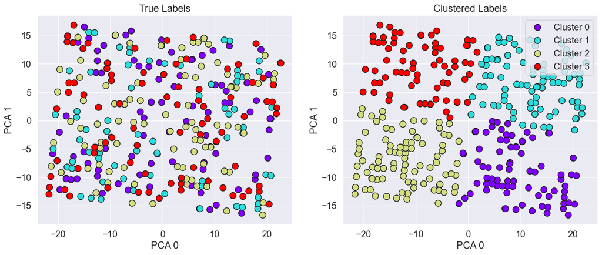

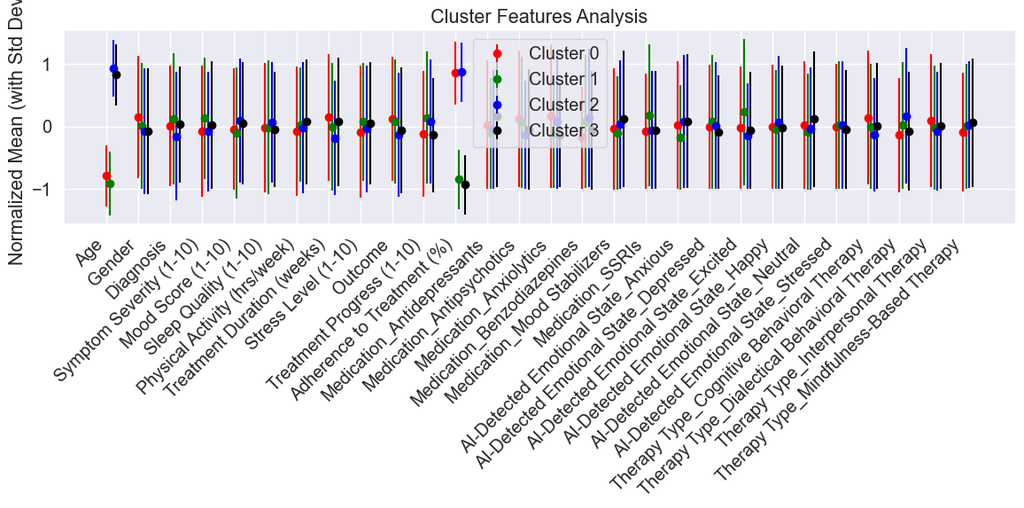

```python
# Apply a kmean clustering here
# KMeans crucial parameters: n_clusters, init, n_init, max_iter, random_state
kmeans = KMeans(n_clusters=4, init='k-means++', n_init=10, max_iter=300, random_state=42)
cluster_labels = kmeans.fit_predict(X)

cluster_counts = Counter(cluster_labels)
print(f"Algorithm found {len(cluster_counts)} clusters.")
print("Points per cluster:", cluster_counts)
true_label_counts = Counter(true_labels)
print(f"True labels have {len(true_label_counts)} clusters.")
print("Points per cluster for true labels:", true_label_counts)

# Silhouette Score
print(f"Silhouette Score: {silhouette_score(X, cluster_labels)}\n")

# Plot true labels vs. clustering results
plot_true_vs_clustered(X_pca, true_labels, cluster_labels)
plot_mean_all_feature(X,cluster_labels)
```

#### Part_4: Propensity Score Matching for Causality

Now we want to see the causality from genders.

```python
# Keep only the specified columns
custom_df = custom_df[[
                       'Age',
                       'Gender',
                       'Symptom Severity (1-10)',
                       'Mood Score (1-10)',
                       'Sleep Quality (1-10)',
                       'Physical Activity (hrs/week)',
                       'Treatment Duration (weeks)',
                       'Treatment Progress (1-10)',
                       'Adherence to Treatment (%)',
                       'Stress Level (1-10)',
                       'Outcome'
                       ]]

# Add an index column
custom_df = custom_df.reset_index(drop=True)
custom_df['Index'] = custom_df.index
```

```python
psm = PsmPy(
    custom_df,
    treatment='Gender',  # The treatment variable
    indx='Index'  # The index of samples
)

# Calculate Propensity Scores
psm.logistic_ps(balance=True)
print(set(psm.predicted_data['propensity_score']))
```

```
{0.42307332544575527, 0.4333985115822099, 0.6495176810402663, 0.622562771620772, 0.5795637411136818, 0.645919583743706, 0.796219253502743, 0.5589703165784332, 0.736809324357866, 0.37711095239887804, 0.66335700017828, 0.34811539041709627, 0.2626748629521357, 0.8118577439883815, 0.28268351359822047, 0…
```

Check for the Common Support

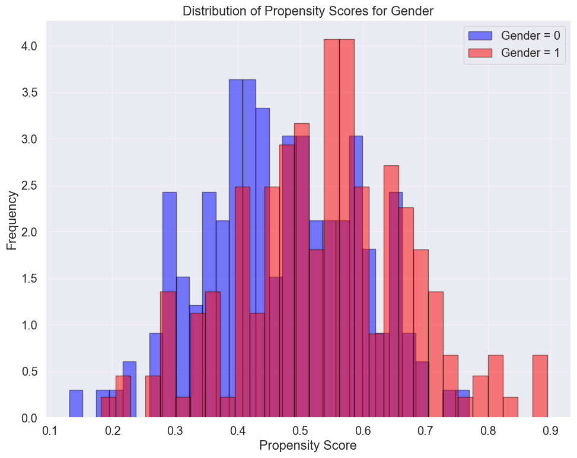

```python
# Separate propensity scores for each group
gender_0_scores = psm.predicted_data[psm.predicted_data['Gender'] == 0]['propensity_score']
gender_1_scores = psm.predicted_data[psm.predicted_data['Gender'] == 1]['propensity_score']


# Plot the histogram as the distributions for Propensity Scores
plt.hist(gender_0_scores, bins=30, alpha=0.5, label='Gender = 0', color='blue', edgecolor='black', density=True)
plt.hist(gender_1_scores, bins=30, alpha=0.5, label='Gender = 1', color='red', edgecolor='black', density=True)

# Add labels, title, and legend
plt.title('Distribution of Propensity Scores for Gender')
plt.xlabel('Propensity Score')
plt.ylabel('Frequency')
plt.legend()
plt.grid(alpha=0.4)
plt.tight_layout()

# Display the plot
plt.show()
```

Most scores fall between 0.1-0.7 - No extreme values, meaning no group is completely distinct.

Group 1 skews slightly higher - More of their scores cluster in the 0.5-0.7 range, suggesting some systematic differences in their traits vs. Group 0.

Moderate overlap - The curves intersect enough for reasonable comparisons.

```python
def nearest_neighbor_matching(data, treatment_col, propensity_col):

    # Separate treated and untreated units
    treated = data[data[treatment_col] == 1].copy()
    control = data[data[treatment_col] == 0].copy()

    # Check if the control group is empty
    if len(control) == 0:
        raise ValueError("Control group is empty, cannot perform matching.")

    # Create an empty list to store matched pairs
    matched_pairs = []

    # Loop through each treated unit
    for treated_idx, treated_row in treated.iterrows():

        # Check if there are any control samples left
        if len(control) == 0:
            break

        # Calculate the absolute differences in propensity scores with control units
        control['distance'] = np.abs(control[propensity_col] - treated_row[propensity_col])

        # Find the control unit with the smallest distance
        closest_control_idx = control['distance'].idxmin()

        # Append the matched pair (treated index, control index)
        matched_pairs.append((treated_idx, closest_control_idx))

        # Remove the matched control unit from the pool (without replacement)
        control = control.drop(index=closest_control_idx)

    return matched_pairs
```

```python
# Use the above function to do the matching
matched_pairs = nearest_neighbor_matching(psm.predicted_data, treatment_col="Gender", propensity_col="propensity_score")

# Display the matched pairs
print("Matched Pairs (treated_index, control_index):")
print(len(matched_pairs))
```

```
Matched Pairs (treated_index, control_index):
155
```

```python
display(matched_pairs)
```

[output not shown]

[output cut: 100 more lines]

```
 (171, 273),
 (172, 277),
 (173, 0),
 (174, 186),
 (175, 4),
 (176, 219),
 (177, 12),
 (178, 200),
 (179, 15),
 (180, 21),
 (181, 268),
 (182, 23),
 (183, 28),
 (184, 20),
 (185, 11)]
```

Assess Covariate Balance by SMD

```python
def calculate_smd(df, matched_pairs, covariates):

    # Extract matched data
    treated_indices, control_indices = zip(*matched_pairs)
    treated_group = df.loc[list(treated_indices)]
    control_group = df.loc[list(control_indices)]

    smd_results = {}

    for covariate in covariates:
        # Calculate means and standard deviations
        treated_mean = treated_group[covariate].mean()
        control_mean = control_group[covariate].mean()
        treated_std = treated_group[covariate].std()
        control_std = control_group[covariate].std()

        # Pooled standard deviation
        pooled_std = np.sqrt(
            ((len(treated_group) - 1) * treated_std ** 2 + (len(control_group) - 1) * control_std ** 2)
            / (len(treated_group) + len(control_group) - 2)
        )

        # Calculate SMD
        smd = abs(treated_mean - control_mean) / pooled_std
        smd_results[covariate] = smd

    return smd_results
```

```python
covariates = [
    'Age',
    'Symptom Severity (1-10)',
    'Mood Score (1-10)',
    'Sleep Quality (1-10)',
    'Physical Activity (hrs/week)',
    'Treatment Duration (weeks)',
    'Treatment Progress (1-10)',
    'Adherence to Treatment (%)',
    'Stress Level (1-10)',
    'Outcome'
                ]
smd_results = calculate_smd(psm.predicted_data, matched_pairs, covariates)

# Display Results
print("Standardized Mean Differences (SMD):")
for covariate, smd in smd_results.items():
    print(f"{covariate}: {smd:.4f}")
```

```
Standardized Mean Differences (SMD):
Age: 0.1080
Symptom Severity (1-10): 0.2014
Mood Score (1-10): 0.1494
Sleep Quality (1-10): 0.2867
Physical Activity (hrs/week): 0.1498
Treatment Duration (weeks): 0.0298
Treatment Progress (1-10): 0.1929
Adherence to Treatment (%): 0.0745
Stress Level (1-10): 0.0038
Outcome: 0.1418
```

The matching worked well overall. Most differences between groups are small (<0.2), meaning they're now comparable.

Well-balanced variables (SMD <0.1 - excellent):

Stress (0.004)

Treatment duration (0.03)

Adherence (0.07)

Adequately balanced (SMD 0.1-0.2 - acceptable):

Mood (0.15)

Physical activity (0.15)

Outcome (0.14)

Treatment progress (0.19)

Symptom severity (0.20)

Needs attention (SMD >0.25):

Sleep quality (0.29) - This is slightly high and might need checking

Calculate ATT as the final result

```python
def calculate_att(df, matched_pairs, outcome_col):

    # Extract treated and control indices from matched pairs
    treated_indices, control_indices = zip(*matched_pairs)

    # Extract the outcome values for treated and control groups
    treated_outcomes = df.loc[list(treated_indices), outcome_col]
    control_outcomes = df.loc[list(control_indices), outcome_col]

    # Compute ATT as the average difference in outcomes
    att = (treated_outcomes.values - control_outcomes.values).mean()

    return att

# Use the above function to compute ATT
outcome_col = 'Sleep Quality (1-10)'
att = calculate_att(psm.predicted_data, matched_pairs, outcome_col)

# Display the result
print(f"Average Treatment Effect on the Treated (ATT): {att:.4f}")
```

```
Average Treatment Effect on the Treated (ATT): -0.4645
```

On average, men rate their sleep quality about half a point lower (0.46 on a 1-10 scale) than women. This suggests something about being male might make sleep worse compared to women.

```python
def calculate_att_binary(df, matched_pairs, outcome_col):

    # Extract treated and control indices from matched pairs
    treated_indices, control_indices = zip(*matched_pairs)

    # Extract the outcome values for treated and control groups
    treated_outcomes = df.loc[list(treated_indices), outcome_col]
    control_outcomes = df.loc[list(control_indices), outcome_col]

    # Compute proportions
    treated_proportion = treated_outcomes.mean()
    control_proportion = control_outcomes.mean()

    # Calculate ATT as the difference in proportions
    att = treated_proportion - control_proportion

    return att

# Just for indication, we should not change variable in the last step
binary_outcome_col = 'Outcome'
att_binary = calculate_att_binary(df=psm.predicted_data, matched_pairs=matched_pairs, outcome_col=binary_outcome_col)

# Display the result
print(f"Average Treatment Effect on the Treated (ATT) for Binary Outcome: {att_binary:.4f}")
```

```
Average Treatment Effect on the Treated (ATT) for Binary Outcome: 0.0710
```

This suggests that receiving the treatment (being male) increases the probability of a positive outcome by about 7 percentage points compared to what would have happened if those same individuals were female, after accounting for other factors. So for men in this study, their maleness appears to give them a small but noticeable advantage in treatment success over their female counterparts.